# CPAWS analysis for British Columbia Marine Protected Network under Climate Change

Colette Wabnitz, Juliano Palacios Abrantes, William W.L. Cheung

```
##   tidyverse          sf          st     janitor  spatialEco   geosphere
##        TRUE        TRUE        TRUE        TRUE        TRUE        TRUE
##      raster       units matrixStats  rmapshaper      igraph
##        TRUE        TRUE        TRUE        TRUE        TRUE
```

# NOTES TO DISCUSS

- Observation, this shapefile has three dimensions, I am guessing there are some areas that are only bottom and this is why?
- Removed the depth component

There are (at least) three ways to reallocate fishing effort as it is in the DBEM. We are using area as follows”

- *Based on area*: To reallocate fishing from protected, we take the area protected/total area of grid cells that contain a protected area and reallocate that protected area proportion to the surrounding cells. This is the most accurate and least conservative (i.e least amount of fishing)

  (area covered by mpa*protection level/total area of grid cells that contain a protected area)/n surrounding grid cells + 1 (or 1.5)

## Grid shapefiles

### Shapefile Data

```
## [1] 3005
```

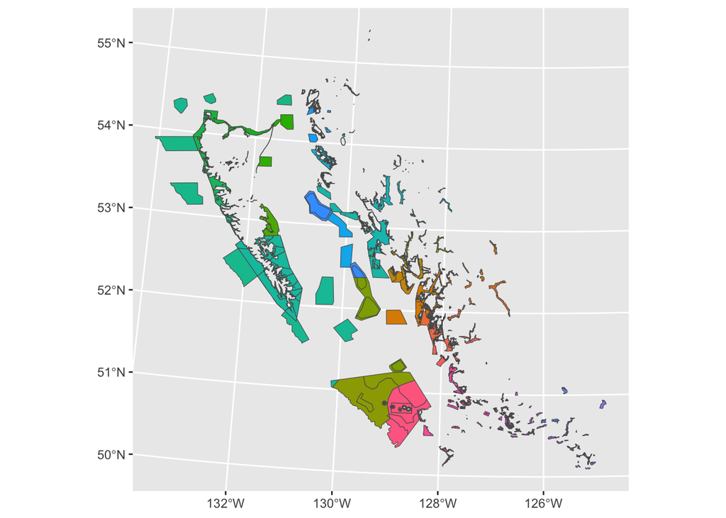

# Grid shapefile

## Identify grids that are MPAs, surrounding an MPA and no-protected

## 1.1 Load in grid data

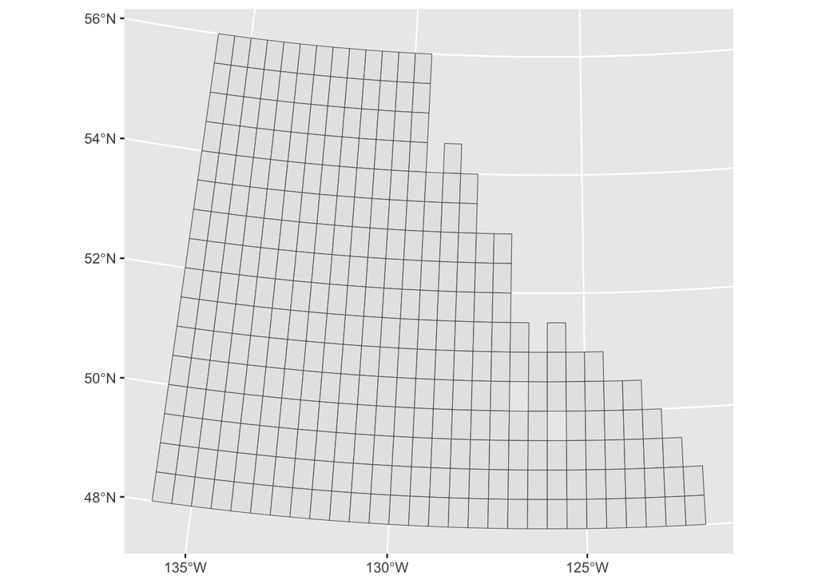

## 1.2 Identify grids that are MPAs

In this step we identify which grid cells have an MPA completely or partially covering it.

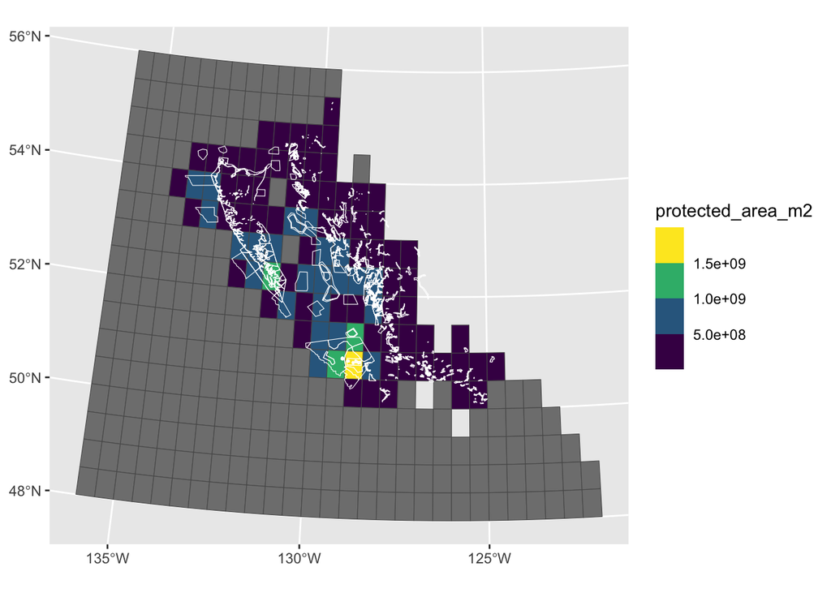

## 1.3 Estimate area

Here we estimate the proportion of the grid cell that is protected using the area protected ($area_p$) relative to the area of the grid cell ($area_g$) in order to reduce fishing effort in grid celss that contain an MPA ($FE_{mpa}$):

$FE_{mpa} = \frac{area_p}{area_g}$

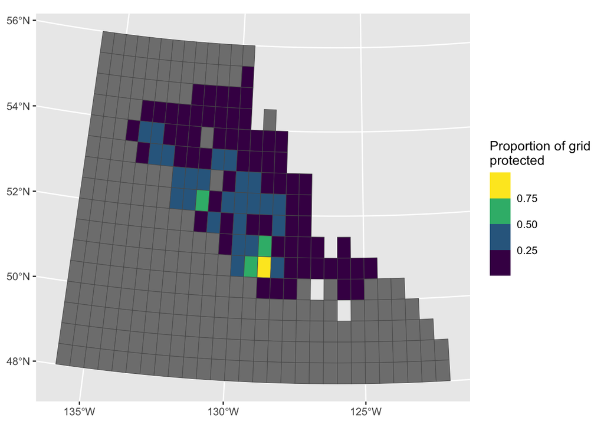

## 1.4 Find surrounding grid cells

Surrounding grid cells are limited to the grid cells immediately adjacent to a grid cell that is cover (complete or partially) by an MPA. The identification of surrounding grid cells is necessary to further re-allocate fishing effort to these cells as they benefit from the biomass spillover.

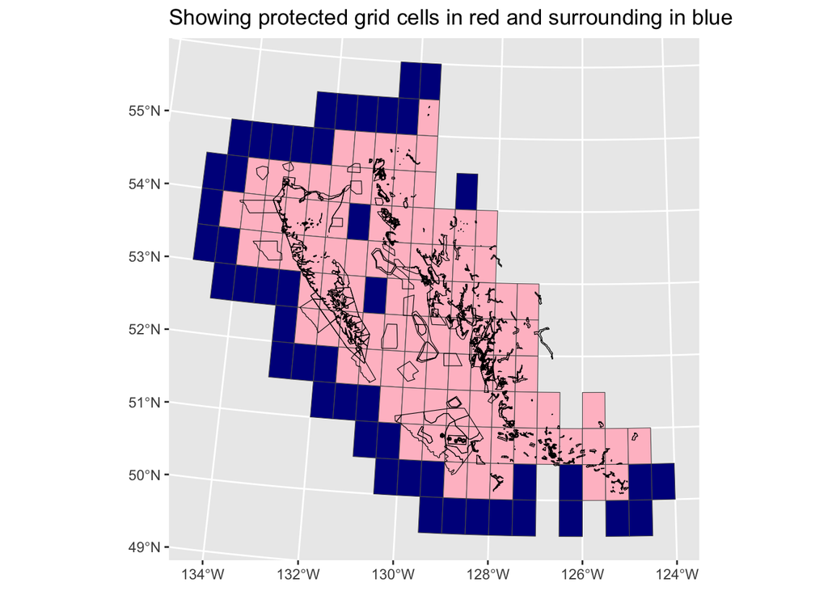

# Reallocate fishing effort

Here we re-allocate fishing effort from the protected grid cells to those surrounding. We do this proportionally to the protected area and the number of surrounding grid cells. Right now, the proportion is accounted from all MPAs and re-distributed to all grid cells, but this can change. For this we first estimate the proportion to be allocated (*PropAllocate*):

$$PropAllocate =
\frac{tot_{mpa}}{tot_{area}}$$

where $tot_{mpa}$ is the sum of the protected area ($m^2$) of all protected grid cells and $tot_{area}$ is the sum of the whole grided area (protected and surrounding). Then, we estimate the allocation of effort by first counting the number of surrounding grid cells and then allocating the proportion to the fishing effort of surrounding cells ($FE_{sur}$):

$$FE_{sur} =
1+\frac{PropAllocate}{n_{surround}}$$
This way, fishing effort in an MPA grid will be reduced by the proportion of the MPA in the grid ($FE_{mpa}$), in surroundings cells will be increased with the proportion allocated ($FE_{sur}$) while all other grid cells (no-protected) will have an DF at MSY.

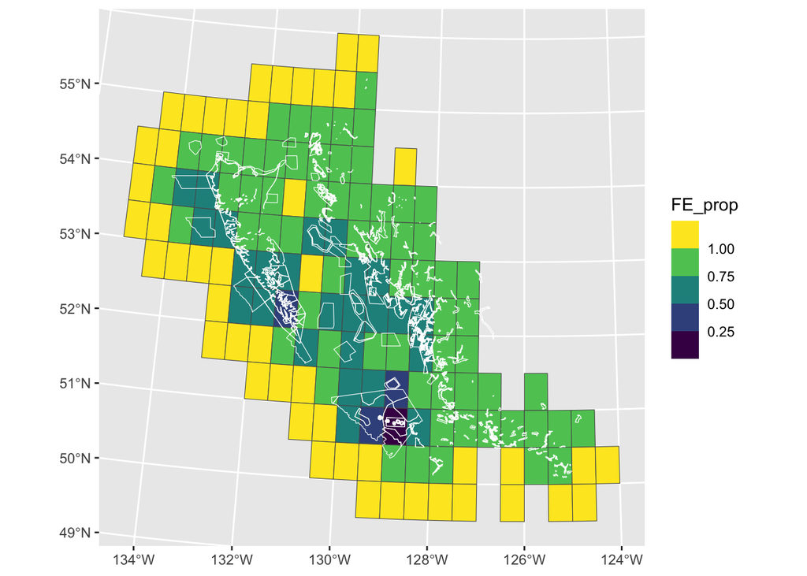